# Autism-Part1

chenhy

2020/6/25

# Find drivers in autism by using NetBID2

## Get significantly up/down regulated genes and drivers

GSE_info:

| GSE_code | GPL | Study.type | Case | Control | Age | Race | Tissue |
| --- | --- | --- | --- | --- | --- | --- | --- |
| GSE64018 | GPL11154 | Expression profiling by high throughput sequencing | 12 | 12 | 15-60 | Harvard Brain Tissue Resource Center | gray matter from all cortical layers (Brodmann areas ba41/42/22) |
| GSE28521 | GPL6883 | Expression profiling by array | 16 | 16 | 5-50 | Harvard Brain Tissue Resource Center | prefrontal cortex |
| GSE27919067 | GPL11154 | Expression profiling by high throughput sequencing | 43 | 45 | 2-67 | Harvard Brain and Tissue Bank | prefrontal cortex |

## Data pre-processing

The path of pre-processing cede is /cluster/home/chenhy/project/neuron_drivers_landscape/src  
The path of QC plot is /cluster/home/chenhy/project/neuron_drivers_landscape/data/{GSE_name}/QC

```r
###### Step 1: Load in gene expression datasets for network construction (exp-load)
#### Download expression dataset from GEO, need to provide GSE ID and GPL ID
### Remove duplicated data & # ID conversion using transfer_tab

###### Step 2: Normalization for the expression dataset (exp-QC)
#### Firstly, view missing values for rows and columns
#### Secondly, the log2 transformation.
#### Thirdly, the quantile normalization across samples.
#### Fourthly, filter out genes with very low expression values (bottom 5%) in most samples (more than 90%).

###### Step 3: Cluster analysis using Kmean and plot result using PCA biplot (pca+kmeans in 2D)
##### Finding confounding factors and remove batch effect

###### Step 4: Get differential expression (DE) / differential activity (DA) for drivers (act-DA)
```

Get regulated drivers:

```r
## input GSE data
gse_list <- list()
for (i in 1:nrow(gse_info_select)) {
  project_main_dir <- "/cluster/home/chenhy/project/neuron_drivers_landscape/data/"
  project_name <- sprintf('Autism_%s_%s',gse_info_select[i,"GSE_code"],gse_info_select[i,"GPL"])
  analysis.par <- list()
  analysis.par$out.dir.DATA <- file.path(project_main_dir,project_name,"DATA/")
  NetBID.loadRData(analysis.par=analysis.par,step='ms-tab')
  gse_list[[gse_info_select[i,"GSE_code"]]] <-  analysis.par
  rm(analysis.par)
}
```

### PCA for GSE27919067 cal.eset

Data processing details: 数据已矫正批次效应

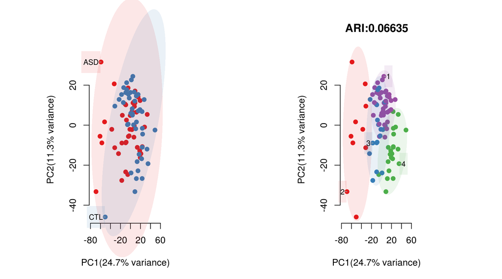

```
## Sample_AN00493_ba9_104  Sample_AN00764_ba9_61  Sample_AN01570_ba9_58
##                      2                      3                      4
## Sample_AN01971_ba9_1st  Sample_AN03345_ba9_79  Sample_AN06420_ba9_52
##                      2                      3                      1
## Sample_AN08043_ba9_1st  Sample_AN08166_ba9_85 Sample_AN08792_ba9_101
##                      1                      1                      1
## Sample_AN09714_ba9_1st Sample_AN09730_ba9_118 Sample_AN11989_ba9_109
##                      1                      3                      1
##  Sample_AN12457_ba9_34  Sample_AN13872_ba9_49  Sample_AN16115_ba9_70
##                      1                      4                      2
##  Sample_AN16641_ba9_73  Sample_AN17254_ba9_98 Sample_AN17515_ba9_1st
##                      3                      2                      1
## Sample_AN19511_ba9_112 Sample_UMB4334_ba9_1st Sample_UMB4849_ba9_2nd
##                      3                      3                      3
## Sample_UMB5115_ba9_2nd Sample_UMB5144_ba9_2nd Sample_UMB5278_ba9_1st
##                      1                      3                      4
## Sample_UMB5308_ba9_2nd Sample_UMB5340_ba9_2nd Sample_UMB4999_ba9_2nd
##                      3                      1                      1
## Sample_UMB5027_ba9_1st Sample_UMB5297_ba9_1st Sample_AN03632_ba9_2nd
##                      2                      2                      1
## Sample_AN04682_ba9_1st Sample_AN03935_ba9_2nd        AN05983_ba9_3rd
##                      2                      3                      4
##        AN09402_ba9_3rd        AN11931_ba9_3rd Sample_AN14762_ba9_1st
##                      4                      4                      3
##  Sample_AN17138_ba9_43        UMB1376_ba9_3rd Sample_UMB1578_ba9_2nd
##                      3                      4                      1
##        UMB4337_ba9_3rd Sample_UMB4842_ba9_2nd Sample_UMB5079_ba9_2nd
##                      3                      1                      1
## Sample_UMB5163_ba9_2nd Sample_UMB5168_ba9_2nd Sample_UMB5242_ba9_1st
##                      3                      1                      3
## Sample_UMB5342_ba9_2nd        AN00142_ba9_3rd  Sample_AN00544_ba9_16
##                      1                      4                      1
##  Sample_AN01125_ba9_22  Sample_AN01410_ba9_67 Sample_AN03217_ba9_2nd
##                      1                      1                      2
##  Sample_AN03217_ba9_91  Sample_AN04479_ba9_10  Sample_AN07176_ba9_13
##                      1                      1                      1
##  Sample_AN07176_ba9_96        AN07444_ba9_3rd Sample_AN08161_ba9_1st
##                      1                      4                      1
## Sample_AN10028_ba9_115 Sample_AN10679_ba9_1st Sample_AN10723_ba9_1st
##                      1                      1                      1
##  Sample_AN10833_ba9_46        AN11864_ba9_3rd        AN12137_ba9_3rd
##                      1                      4                      4
##   Sample_AN12240_ba9_7  Sample_AN13295_ba9_88 Sample_AN14757_ba9_2nd
##                      1                      1                      1
## Sample_AN15088_ba9_1st  Sample_AN15566_ba9_28 Sample_AN17425_ba9_1st
##                      1                      1                      1
##  Sample_AN17425_ba9_31        AN19442_ba9_3rd  Sample_AN19760_ba9_25
##                      1                      4                      1
## Sample_UMB4590_ba9_1st            AN14829_ba9            AN15451_ba9
##                      3                      2                      3
##            UMB1185_ba9            UMB1407_ba9            UMB1499_ba9
##                      4                      4                      4
##            UMB1714_ba9            UMB4334_ba9            UMB4670_ba9
##                      4                      3                      4
##            UMB4787_ba9            UMB5023_ba9            UMB5176_ba9
##                      4                      4                      4
##            UMB5303_ba9            UMB5309_ba9            UMB5391_ba9
##                      1                      4                      4
##            UMB5558_ba9
##                      2
```

### PCA for GSE27919067 merge.ac.eset

Data processing details: 数据已矫正批次效应

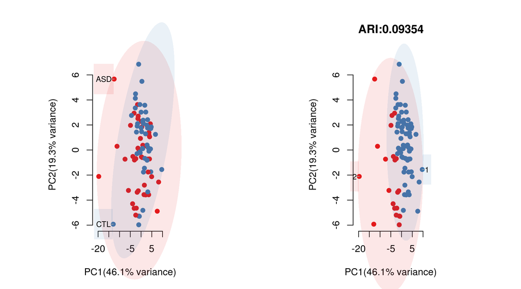

```
## Sample_AN00493_ba9_104  Sample_AN00764_ba9_61  Sample_AN01570_ba9_58
##                      2                      1                      1
## Sample_AN01971_ba9_1st  Sample_AN03345_ba9_79  Sample_AN06420_ba9_52
##                      2                      2                      1
## Sample_AN08043_ba9_1st  Sample_AN08166_ba9_85 Sample_AN08792_ba9_101
##                      1                      1                      1
## Sample_AN09714_ba9_1st Sample_AN09730_ba9_118 Sample_AN11989_ba9_109
##                      1                      2                      1
##  Sample_AN12457_ba9_34  Sample_AN13872_ba9_49  Sample_AN16115_ba9_70
##                      2                      1                      2
##  Sample_AN16641_ba9_73  Sample_AN17254_ba9_98 Sample_AN17515_ba9_1st
##                      1                      2                      1
## Sample_AN19511_ba9_112 Sample_UMB4334_ba9_1st Sample_UMB4849_ba9_2nd
##                      2                      2                      1
## Sample_UMB5115_ba9_2nd Sample_UMB5144_ba9_2nd Sample_UMB5278_ba9_1st
##                      1                      1                      1
## Sample_UMB5308_ba9_2nd Sample_UMB5340_ba9_2nd Sample_UMB4999_ba9_2nd
##                      1                      1                      1
## Sample_UMB5027_ba9_1st Sample_UMB5297_ba9_1st Sample_AN03632_ba9_2nd
##                      2                      2                      1
## Sample_AN04682_ba9_1st Sample_AN03935_ba9_2nd        AN05983_ba9_3rd
##                      2                      2                      1
##        AN09402_ba9_3rd        AN11931_ba9_3rd Sample_AN14762_ba9_1st
##                      1                      2                      1
##  Sample_AN17138_ba9_43        UMB1376_ba9_3rd Sample_UMB1578_ba9_2nd
##                      2                      1                      1
##        UMB4337_ba9_3rd Sample_UMB4842_ba9_2nd Sample_UMB5079_ba9_2nd
##                      2                      1                      1
## Sample_UMB5163_ba9_2nd Sample_UMB5168_ba9_2nd Sample_UMB5242_ba9_1st
##                      1                      1                      1
## Sample_UMB5342_ba9_2nd        AN00142_ba9_3rd  Sample_AN00544_ba9_16
##                      1                      1                      1
##  Sample_AN01125_ba9_22  Sample_AN01410_ba9_67 Sample_AN03217_ba9_2nd
##                      1                      1                      2
##  Sample_AN03217_ba9_91  Sample_AN04479_ba9_10  Sample_AN07176_ba9_13
##                      1                      1                      1
##  Sample_AN07176_ba9_96        AN07444_ba9_3rd Sample_AN08161_ba9_1st
##                      1                      1                      1
## Sample_AN10028_ba9_115 Sample_AN10679_ba9_1st Sample_AN10723_ba9_1st
##                      1                      1                      1
##  Sample_AN10833_ba9_46        AN11864_ba9_3rd        AN12137_ba9_3rd
##                      1                      1                      1
##   Sample_AN12240_ba9_7  Sample_AN13295_ba9_88 Sample_AN14757_ba9_2nd
##                      1                      1                      1
## Sample_AN15088_ba9_1st  Sample_AN15566_ba9_28 Sample_AN17425_ba9_1st
##                      1                      1                      1
##  Sample_AN17425_ba9_31        AN19442_ba9_3rd  Sample_AN19760_ba9_25
##                      1                      1                      1
## Sample_UMB4590_ba9_1st            AN14829_ba9            AN15451_ba9
##                      1                      2                      1
##            UMB1185_ba9            UMB1407_ba9            UMB1499_ba9
##                      1                      1                      2
##            UMB1714_ba9            UMB4334_ba9            UMB4670_ba9
##                      1                      2                      1
##            UMB4787_ba9            UMB5023_ba9            UMB5176_ba9
##                      1                      1                      1
##            UMB5303_ba9            UMB5309_ba9            UMB5391_ba9
##                      1                      1                      1
##            UMB5558_ba9
##                      2
```

### PCA for GSE28521 cal.eset

Data processing details: 数据没有协变量，未矫正批次效应

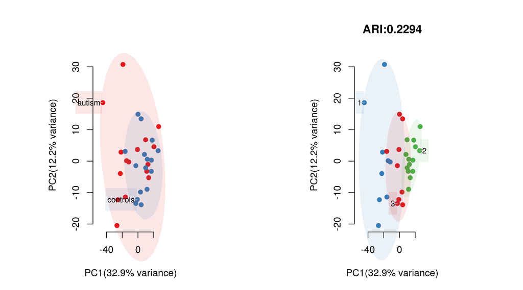

```
## GSM706412 GSM706413 GSM706414 GSM706415 GSM706416 GSM706417 GSM706418 GSM706419
##         3         1         1         2         1         1         1         1
## GSM706420 GSM706421 GSM706422 GSM706423 GSM706424 GSM706425 GSM706426 GSM706427
##         2         2         2         1         2         1         1         2
## GSM706428 GSM706429 GSM706430 GSM706431 GSM706432 GSM706433 GSM706434 GSM706435
##         3         2         2         3         2         2         3         3
## GSM706436 GSM706437 GSM706438 GSM706439 GSM706440 GSM706441 GSM706442 GSM706443
##         2         3         2         3         3         2         3         2
```

### PCA for GSE28521 merge.ac.eset

Data processing details: 数据没有协变量，未矫正批次效应

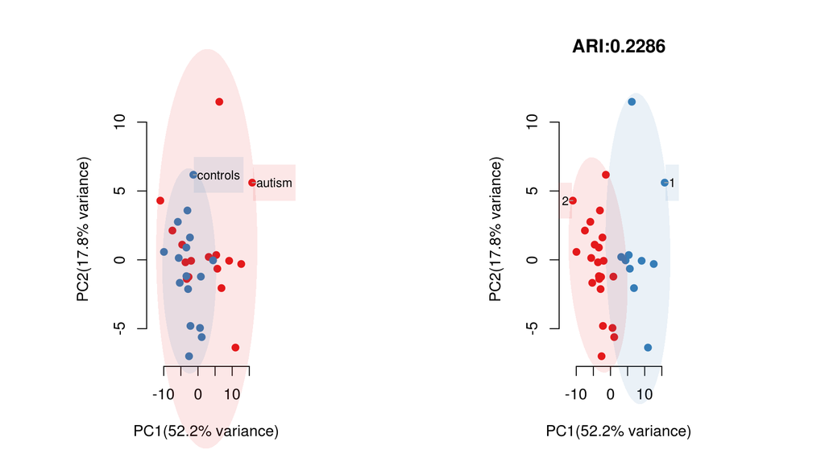

```
## GSM706412 GSM706413 GSM706414 GSM706415 GSM706416 GSM706417 GSM706418 GSM706419
##         2         1         1         2         1         1         1         1
## GSM706420 GSM706421 GSM706422 GSM706423 GSM706424 GSM706425 GSM706426 GSM706427
##         2         2         2         1         2         1         1         2
## GSM706428 GSM706429 GSM706430 GSM706431 GSM706432 GSM706433 GSM706434 GSM706435
##         2         2         2         2         2         2         2         2
## GSM706436 GSM706437 GSM706438 GSM706439 GSM706440 GSM706441 GSM706442 GSM706443
##         2         2         2         2         1         2         2         2
```

### PCA for GSE64018 cal.eset

Data processing details: 根据原文表述数据可能已矫正批次效应

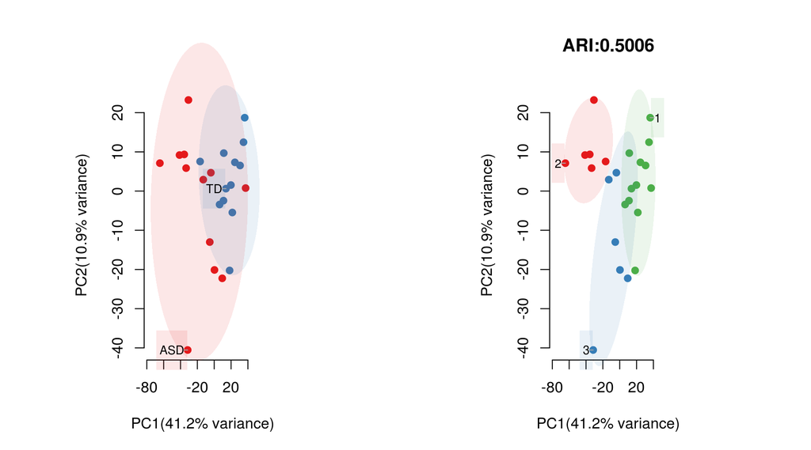

```
## GSM1562865 GSM1562866 GSM1562867 GSM1562868 GSM1562869 GSM1562870 GSM1562871
##          2          3          3          3          2          2          1
## GSM1562872 GSM1562873 GSM1562874 GSM1562875 GSM1562876 GSM1562877 GSM1562878
##          3          2          3          3          2          1          1
## GSM1562879 GSM1562880 GSM1562881 GSM1562882 GSM1562883 GSM1562884 GSM1562885
##          1          1          1          1          1          1          2
## GSM1562886 GSM1562887 GSM1562888
##          1          1          1
```

### PCA for GSE64018 merge.ac.eset

Data processing details: 根据原文表述数据可能已矫正批次效应

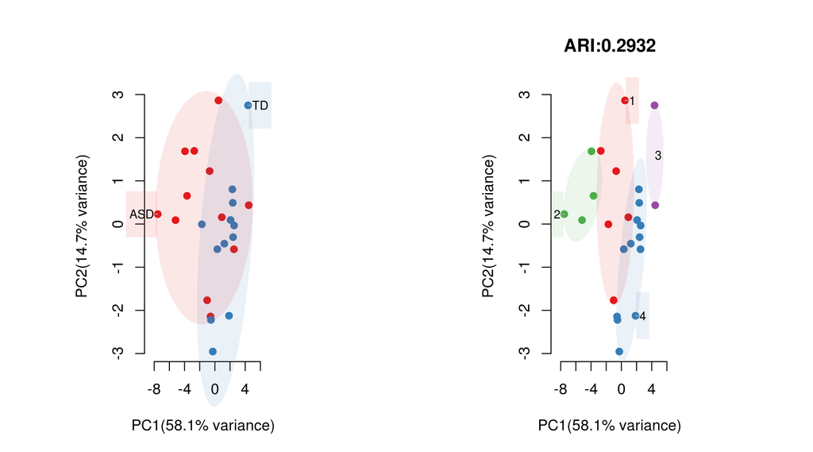

```
## GSM1562865 GSM1562866 GSM1562867 GSM1562868 GSM1562869 GSM1562870 GSM1562871
##          1          1          1          4          2          2          3
## GSM1562872 GSM1562873 GSM1562874 GSM1562875 GSM1562876 GSM1562877 GSM1562878
##          1          2          1          4          2          4          4
## GSM1562879 GSM1562880 GSM1562881 GSM1562882 GSM1562883 GSM1562884 GSM1562885
##          4          4          4          4          3          4          1
## GSM1562886 GSM1562887 GSM1562888
##          4          4          4
```

## Plot Venn graph

Significantly different expression genes as a proportion of all genes

```
## [1] "GSE27919067:0.103"
```

```
## [1] "GSE64018:0.106"
```

```
## [1] "GSE28521:0.1"
```

## The overlap of all protein-conding genes in the three raw datasets

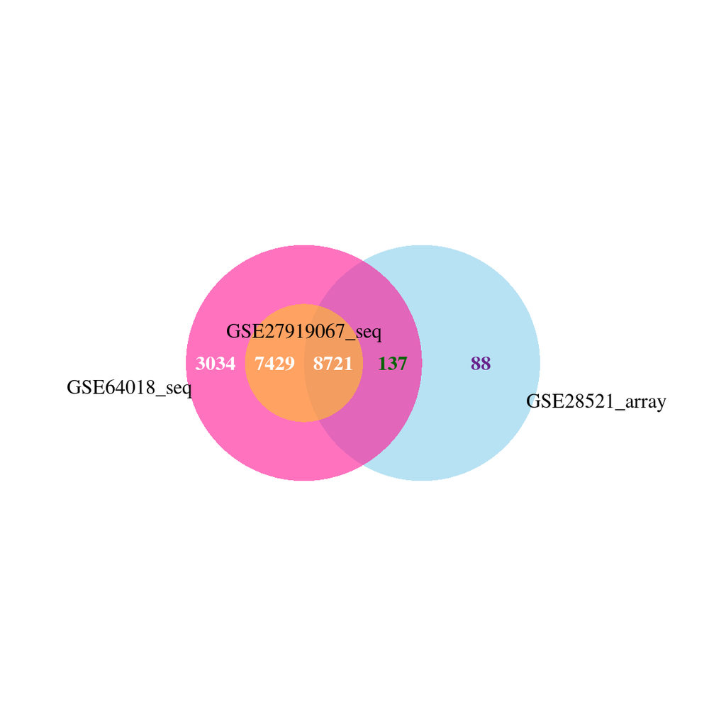

## The overlap of all protein-conding genes in the three processed datasets

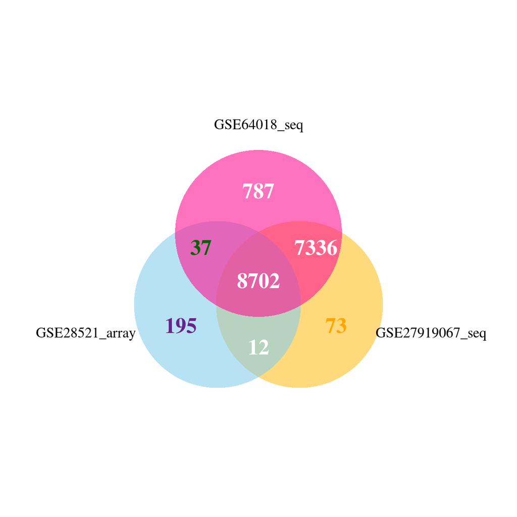

## The overlap of differential genes in the three datasets is shown below

Up genes

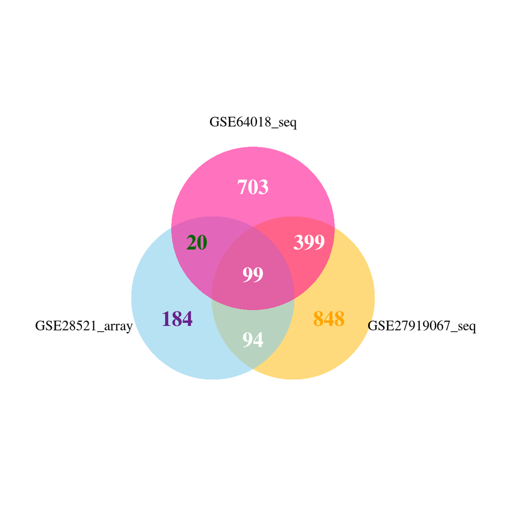

Down genes

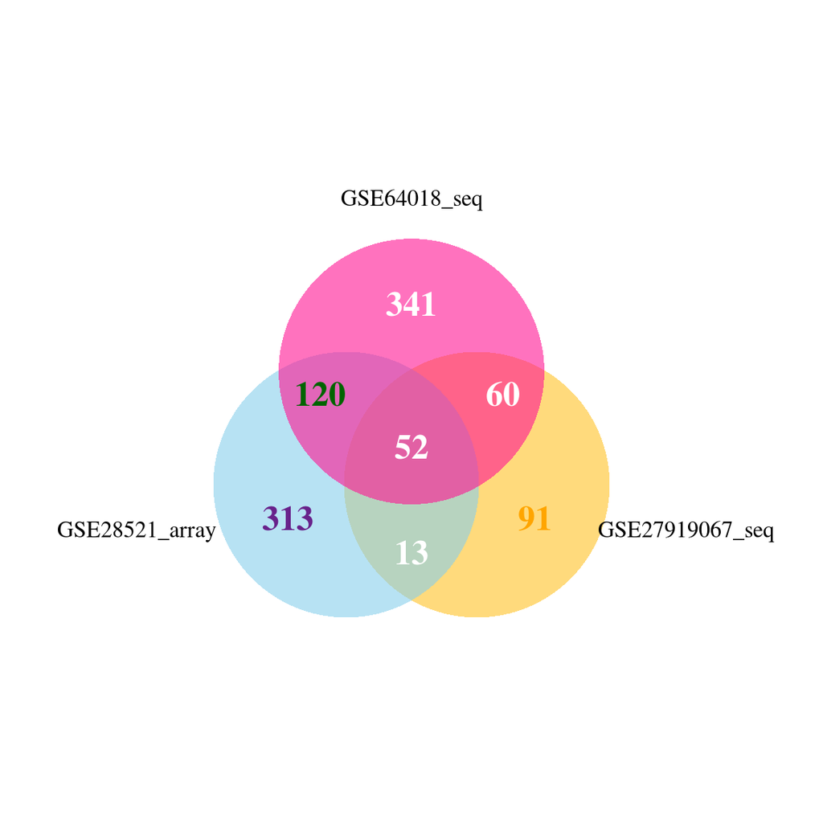

### The expression of up/down regulated genes in GSE27919067

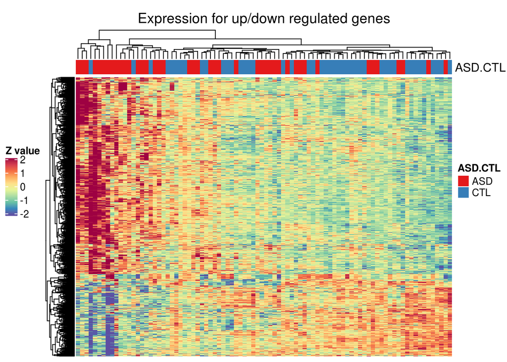

```
## [1] TRUE
```

### The expression of up/down regulated genes in GSE64018

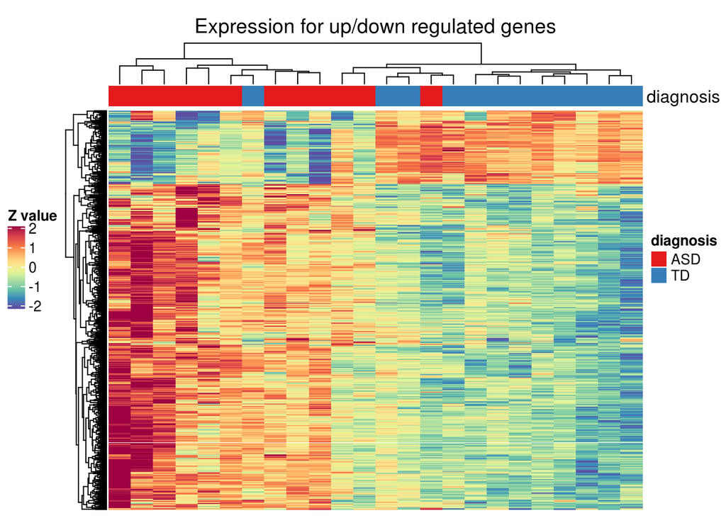

```
## [1] TRUE
```

### The expression of up/down regulated genes in GSE28521

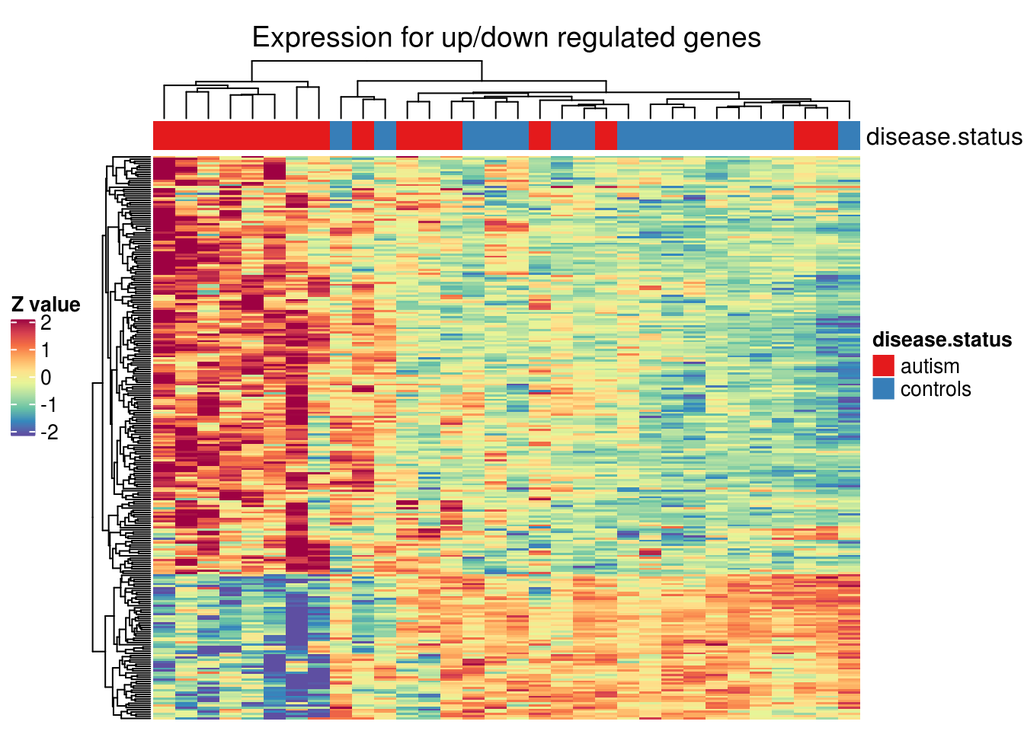

```
## [1] TRUE
```

## Intersection with public reported genes

check the intersection of up/down with public reported autism related genes in DisGenet

```
[1] "Tht number of intersect gene is 862. The number of DisGenet reported gene in the overlap of DEG is 71, mean Disease-related-score in DisGenet equals 0.069"
```

```
[1] "The number of SFari reported gene in the overlap of DEG is 44, mean Disease-related-score in SFari equals 2.548"
```

## Plot Venn graph

Significantly different drivers as a proportion of all drivers

```
## [1] "GSE27919067:0.099"
```

```
## [1] "GSE64018:0.11"
```

```
## [1] "GSE28521:0.103"
```

## The overlap of drivers in the three datasets is shown below

Up drivers

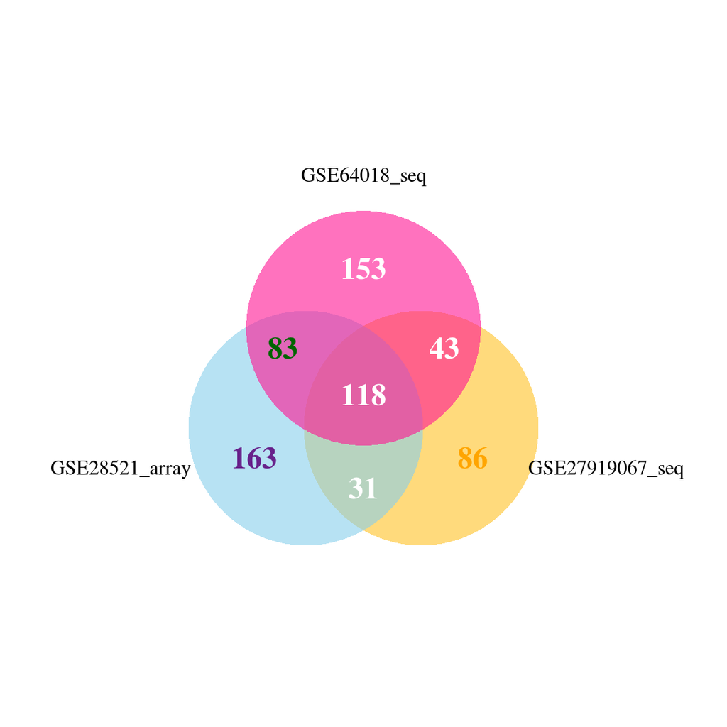

Down drivers

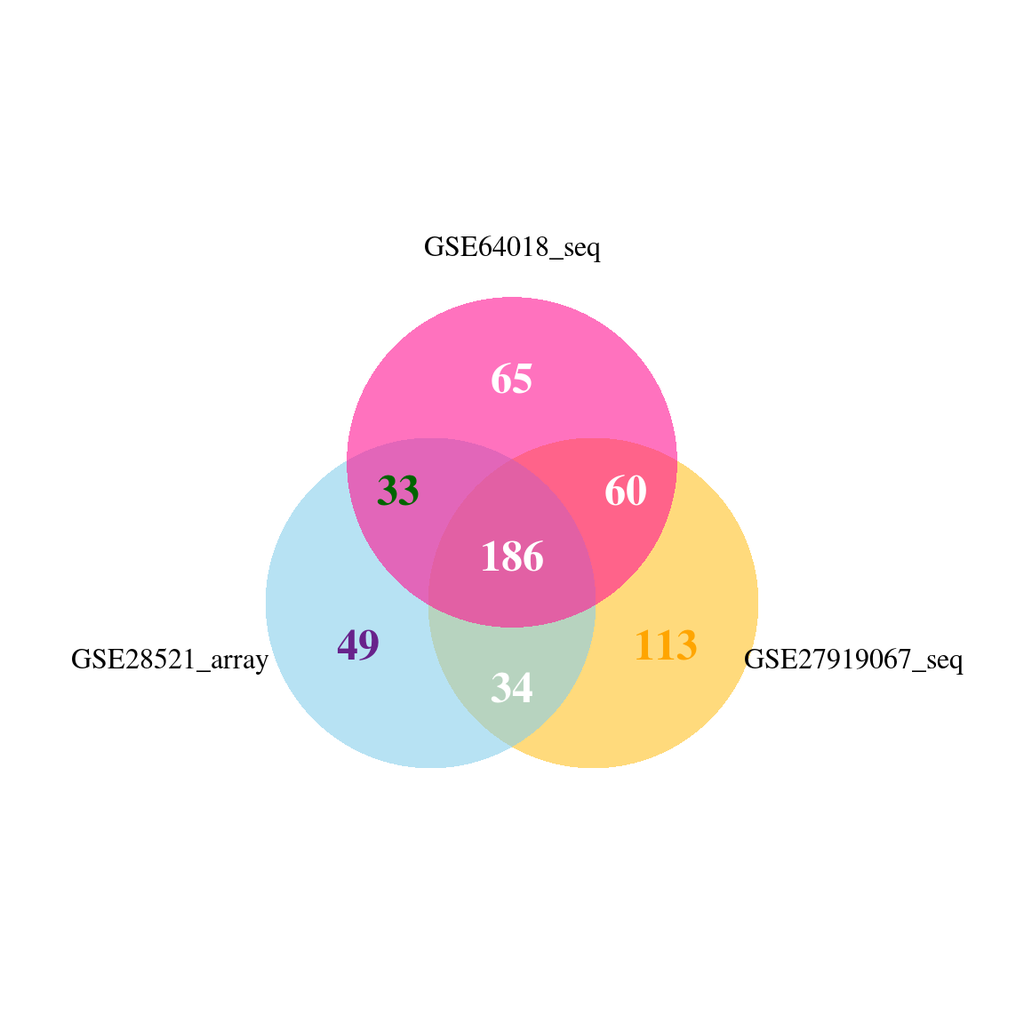

## Plot pheatmap of overlaps drivers of GSE27919067,GSE64018 and GSE28521

### The activity of up/down regulated drivers in GSE27919067

```
## [1] "The number of up regulated drivers in GSE27919067 is 192,the percentage of all differential up drivers is 0.29;down regulated drivers is 280,the percentage of all differential down drivers is 0.42"
```

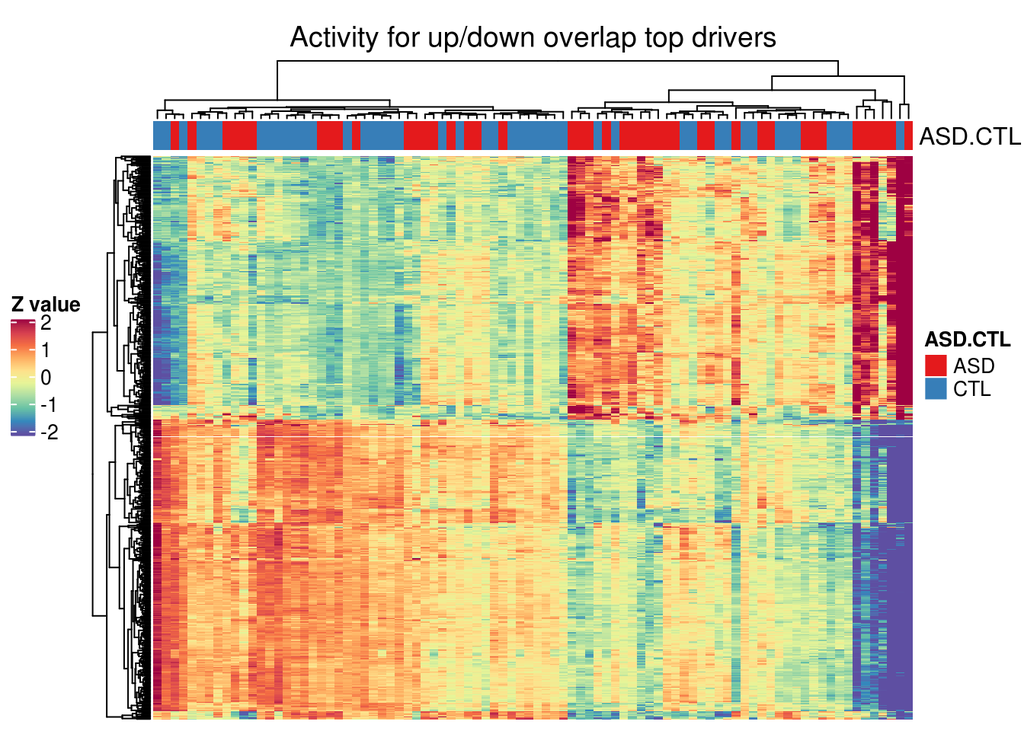

```
## [1] TRUE
```

### The activity of up/down regulated drivers in GSE64018

```
## [1] "The number of up regulated drivers in GSE64018 is 244,the percentage of all differential up drivers is 0.33;down regulated drivers is 279,the percentage of all differential down drivers is 0.38"
```

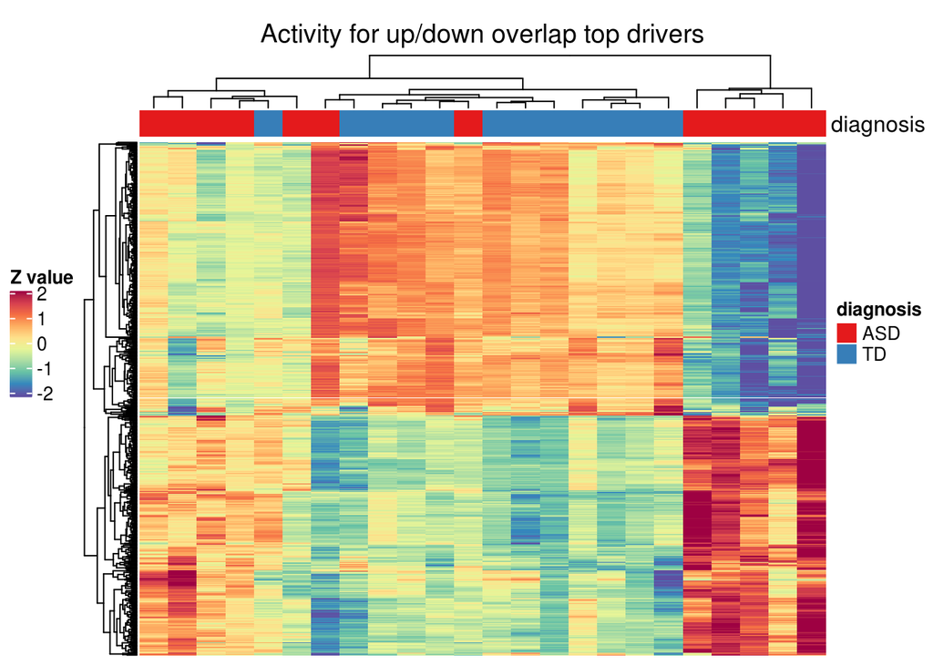

```
## [1] TRUE
```

### The activity of up/down regulated drivers in GSE28521

```
## [1] "The number of up regulated drivers in GSE28521 is 232,the percentage of all differential up drivers is 0.33;down regulated drivers is 253,the percentage of all differential down drivers is 0.36"
```

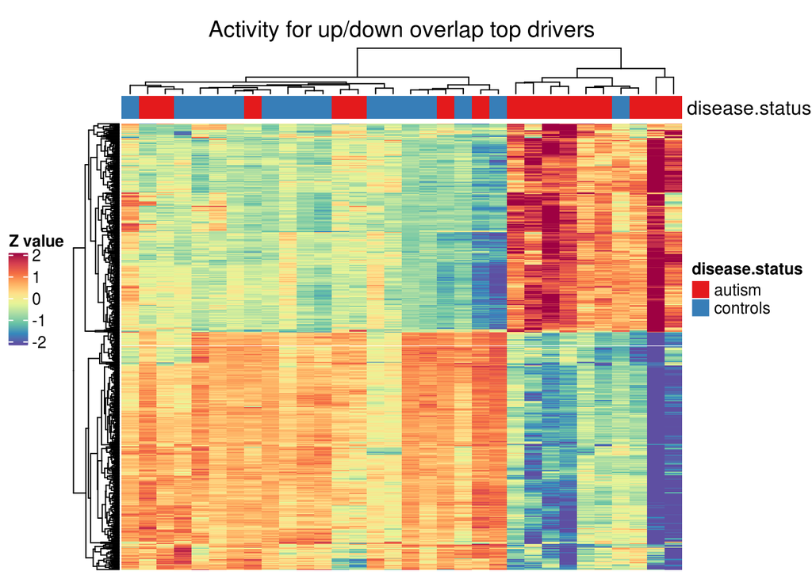

```
## [1] TRUE
```